# Chapter 4: Poisson models

## Big picture

The Poisson distribution is often used for discrete counts, as it has integer support. In this chapter, we show how to extend the methods of Chapter 3 to models that use Poisson likelihoods, and we point out connections to Poisson-family generalized linear models. Also, we make use of link functions as maps between constrained and unconstrained spaces, and show how to include overdispersion in Poisson models, which is often necessary in real-world applications.

#### Learning goals

- parameters and behavior of the Poisson distribution
- log link as a map
- effects sizes in Poisson models
- dependence of mean and variance in non-Gaussian models
- overdispersion: Poisson and negative-binomial
- implementation with `glm` and Stan
- graphical displays
- model checking
- simulation of data & parameter recovery

## Poisson generalized linear models

We have covered general linear models, which by definition assume normally distributed response variables, and in this chapter we cover our first generalized linear model. Generalized linear models (glms) allow for other response distributions, including the Poisson distribution. This is admittedly a subtle distinction.

Poisson glms are defined as follows:

$y \sim Poisson(\lambda)$

$log(\lambda) = X \beta$

Where the log-link is used to map the Poisson distribution’s only parameter $\lambda$ from it’s constrained space $[0, \infty)$ to the unconstrained space $(-\infty, \infty)$, and $X$ is a design matrix as before. Recall that $\lambda$ is the mean and variance of the Poisson distribution, in contrast for example to the Gaussian distribution which has separate parameters for the first and second moments.

Sometimes, it’s desirable to include an offset. For instance, perhaps $y$ is the number of events per unit time, or per square-meter, and each observation has different time intervals or areas sampled. Then, we might be interested in modeling the rate of events per unit (time or meters square), e.g., $\dfrac{\lambda}{t}$, which is in units events per time.

$log(\lambda / t) = X \beta$

$log(\lambda) - log(t) = X \beta$

$log(\lambda) = X \beta + log(t)$

So that now, we can still rely on $y \sim Poisson(\lambda)$, even with varying $t$.

The class of models that utilize the Poisson distribution is far broader than what we can do with glms, but glms provide a common and simple starting point.

## Simulation and estimation

We will demonstrate with a Poisson regression, but maintain the generality of our notation by continuing to make use of the design matrix $X$, so that the applicability to ANOVA, ANCOVA, etc. types of applications remains apparent.

```r
n <- 50
x <- runif(n, -1, 1)
X <- matrix(c(rep(1, n), x), ncol=2)
beta <- c(.5, -1)
lambda <- exp(X %*% beta)
y <- rpois(n, lambda)
```

### Estimation with `glm`

We can obtain maximum likelihood estimates for Poisson glm coefficients, along with frequentist p-values and confidence intervals with the `glm` function.

```r
m <- glm(y ~ x, family=poisson)
summary(m)
```

```
##
## Call:
## glm(formula = y ~ x, family = poisson)
##
## Deviance Residuals:
##     Min       1Q   Median       3Q      Max
## -2.0683  -1.1227   0.1729   0.5292   2.0022
##
## Coefficients:
##             Estimate Std. Error z value Pr(>|z|)
## (Intercept)   0.4294     0.1243   3.456 0.000549 ***
## x            -1.0158     0.1908  -5.323 1.02e-07 ***
## ---
## Signif. codes:  0 '***' 0.001 '**' 0.01 '*' 0.05 '.' 0.1 ' ' 1
##
## (Dispersion parameter for poisson family taken to be 1)
##
##     Null deviance: 83.712  on 49  degrees of freedom
## Residual deviance: 51.479  on 48  degrees of freedom
## AIC: 155.08
##
## Number of Fisher Scoring iterations: 5
```

```r
confint(m)
```

```
##                  2.5 %     97.5 %
## (Intercept)  0.1728317  0.6613987
## x           -1.4015308 -0.6516065
```

Plotting the line of best fit with the data:

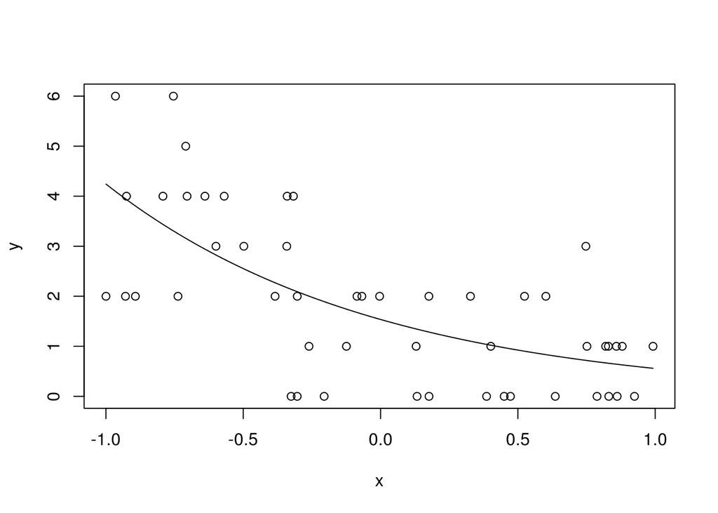

```r
plot(x, y)

xnew <- seq(min(x), max(x), length.out = 100)
lines(xnew, exp(coef(m)[1] + coef(m)[2] * xnew))
```

### Estimation with Stan

Even though Poisson glms are often taught after Gaussian glms, they are in a way simpler, requiring one less parameter. Here is a Stan file `poisson_glm.stan` that can be used generally to fit any Poisson glm without an offset.

```
data {
  int n; // sample size
  int p; // number of coefficients
  matrix[n, p] X;
  int y[n];
}

parameters {
  vector[p] beta;
}

model {
  beta ~ normal(0, 3);
  y ~ poisson_log(X * beta);
}
```

Fitting the model is the same as before:

```r
library(rstan)
X <- matrix(c(rep(1, n), x), ncol = 2)
stan_d <- list(n = nrow(X), p = ncol(X), X = X, y = y)
out <- stan('poisson_glm.stan', data = stan_d)
```

As always, it behooves us evaluate convergence and see whether there may be issues with the MCMC algorithm.

```r
out
```

```
## Inference for Stan model: poisson_glm.
## 4 chains, each with iter=2000; warmup=1000; thin=1;
## post-warmup draws per chain=1000, total post-warmup draws=4000.
##
##           mean se_mean   sd   2.5%    25%    50%    75%  97.5% n_eff Rhat
## beta[1]   0.42    0.00 0.12   0.17   0.33   0.42   0.50   0.64  1259    1
## beta[2]  -1.02    0.01 0.19  -1.40  -1.14  -1.02  -0.90  -0.66  1227    1
## lp__    -20.21    0.03 0.99 -22.71 -20.58 -19.91 -19.51 -19.26  1211    1
##
## Samples were drawn using NUTS(diag_e) at Sun Nov 22 19:43:54 2015.
## For each parameter, n_eff is a crude measure of effective sample size,
## and Rhat is the potential scale reduction factor on split chains (at
## convergence, Rhat=1).
```

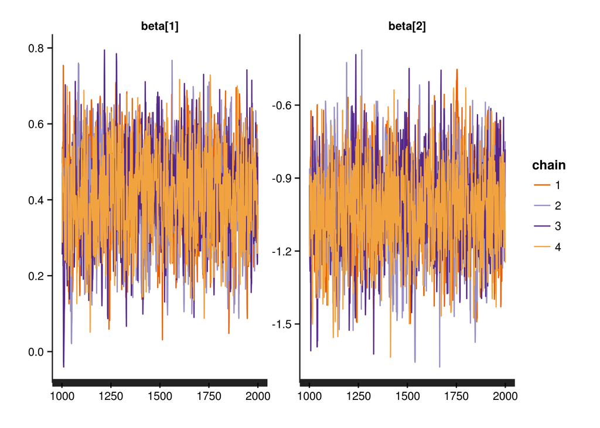

```r
traceplot(out)
```

```
## Showing 80% intervals
```

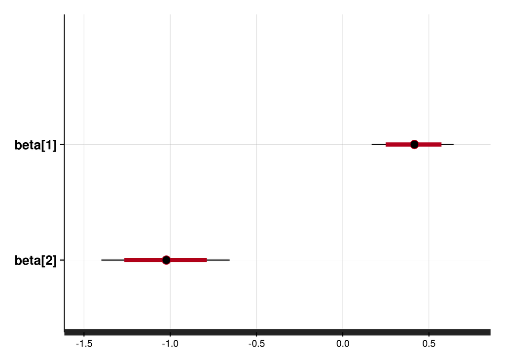

```r
plot(out)
```

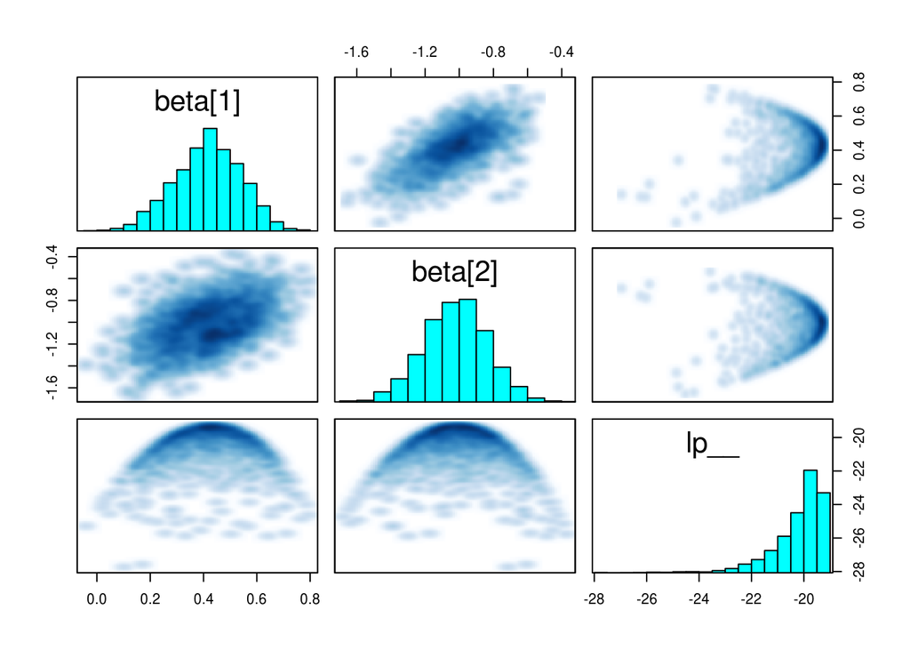

```r
pairs(out)
```

Let’s plot the lines of best fit from the posterior distribution:

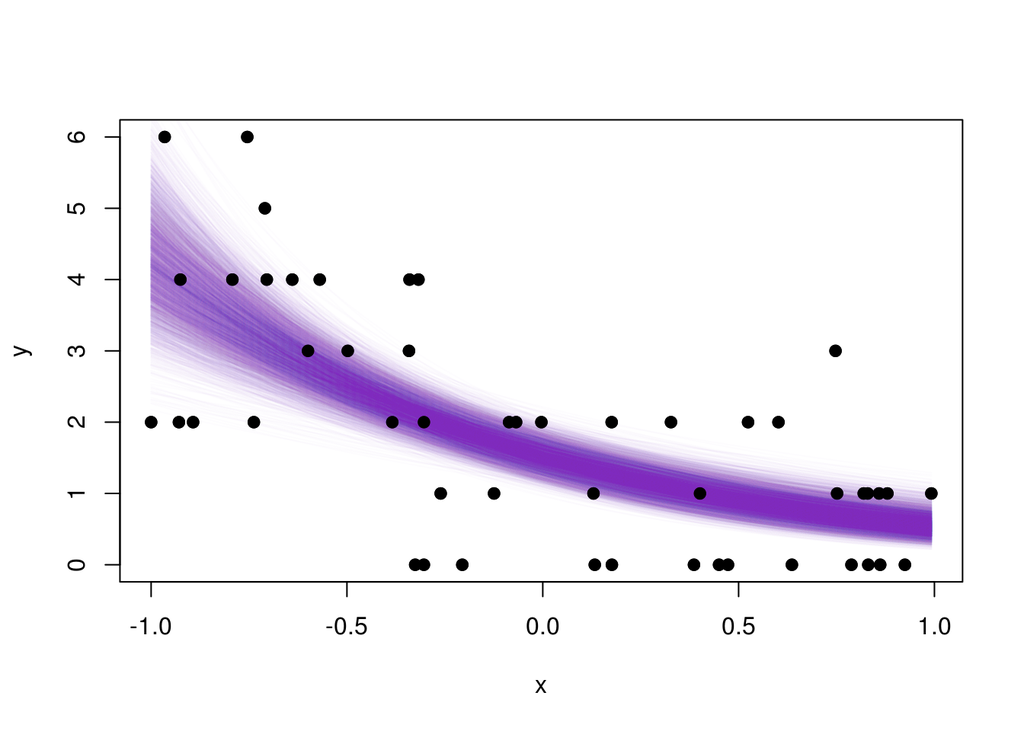

```r
library(scales)
post <- extract(out)
plot(x, y)
n_iter <- length(post$lp__)
for (i in 1:n_iter){
  lines(xnew, exp(post$beta[i, 1] + post$beta[i, 2] * xnew),
        col = alpha('purple3', .01))
}
points(x, y, pch=19)
```

At times, people get confused about why the fits from Poisson glms are not linear, even though we didn’t include any polynomial terms. The model is linear on the link-scale only, so that if we were to plot x vs. $log(\lambda)$, we would see a straight line. There is a lot of good material in Gelman and Hill, Chapter 6 to help with the interpretation of glm parameter estimates. For many applications, visualization is an excellent step towards interpreting model output.

## Overdispersion

For various reasons, the variance of counts in nature tends to be greater than the mean. This can be considered to be extra-Poisson variance. Various strategies exist to account for overdispersion, and here we cover the inclusion of lognormal random effects and also derive the negative binomial distribution as a Poisson distribution with a gamma-distributed $\lambda$.

### Checking for overdispersion

How do you know whether the variance in your data exceeds the variance you would expect in the absence of overdispersion? One general strategy that falls under the class of model diagnostics known as **posterior predictive checks** does the following:

1. For each posterior draw, simulate a new vector of observations.
2. For each simulated vector of observations, calculate some test statistic of interest.
3. Compare the distribution of simulated test statistics to the empirical test statistic.

In this case, it is reasonable to choose the variance of $y$ as the test statistic.

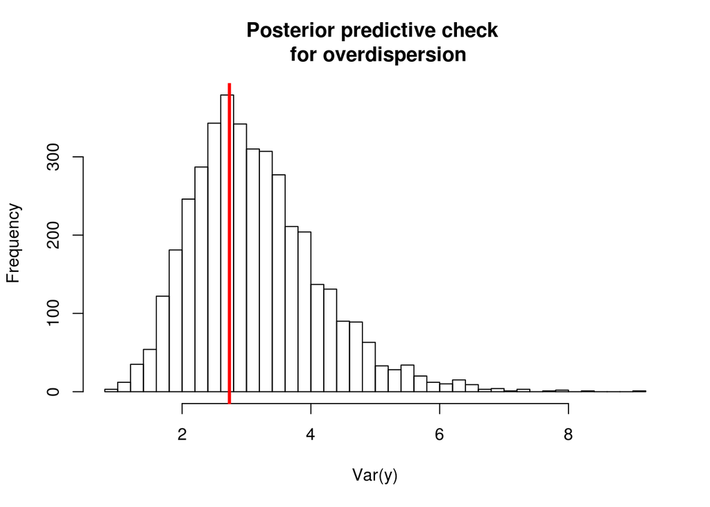

```r
# simulate new observations and store variances
y_new <- array(dim=c(n_iter, n))
var_new <- rep(NA, n_iter)
for (i in 1:n_iter){
  y_new[i, ] <- rpois(n, exp(X %*% post$beta[i, ]))
  var_new[i] <- var(y_new[i, ])
}

# compare distribution of simulated values to the empirical values
hist(var_new, breaks=40, xlab='Var(y)',
     main='Posterior predictive check \n for overdispersion')
abline(v = var(y), col=2, lwd=3)
```

In this case, we can say that the variance in y shown by the red line is perfectly compatible with the model, which makes sense because we generated the data from a Poisson distribution.

Here’s a real world application with overdispersion. The `vegan` package has a dataset of the number of trees in a bunch of 1-hectare plots on Barro Colorado Island. Let’s look at the mean and variance of each species to get a sense for how often Poisson distribution might work:

```r
library(vegan)
library(dplyr)
data(BCI)

# coerce into long form
d <- stack(BCI)
str(d)
```

```
## 'data.frame':    11250 obs. of  2 variables:
##  $ values: int  0 0 0 0 0 0 0 0 0 1 ...
##  $ ind   : Factor w/ 225 levels "Abarema.macradenia",..: 1 1 1 1 1 1 1 1 1 1 ...
```

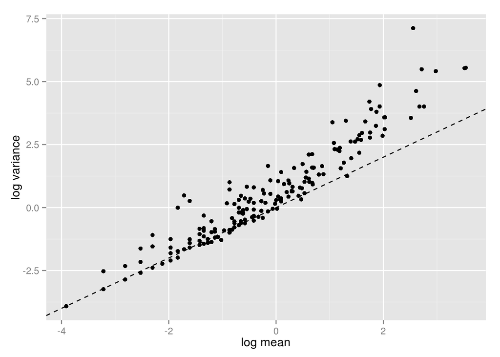

```r
# calculate means and variances
summ_d <- d %>%
  group_by(ind) %>%
  summarize(lmean=log(mean(values)),
            lvar=log(var(values)))
ggplot(summ_d, aes(x=lmean, y=lvar)) +
  geom_point() +
  geom_abline(intecept=0, slope=1, linetype='dashed') +
  xlab("log mean") +
  ylab("log variance")
```

Darn. Looks like the variance exceeds the mean for most of these species. Let’s put together a simple model for the abundance of the species *Trichilia pallida*, where we seek to estimate the mean density for the island based on the sampled plots.

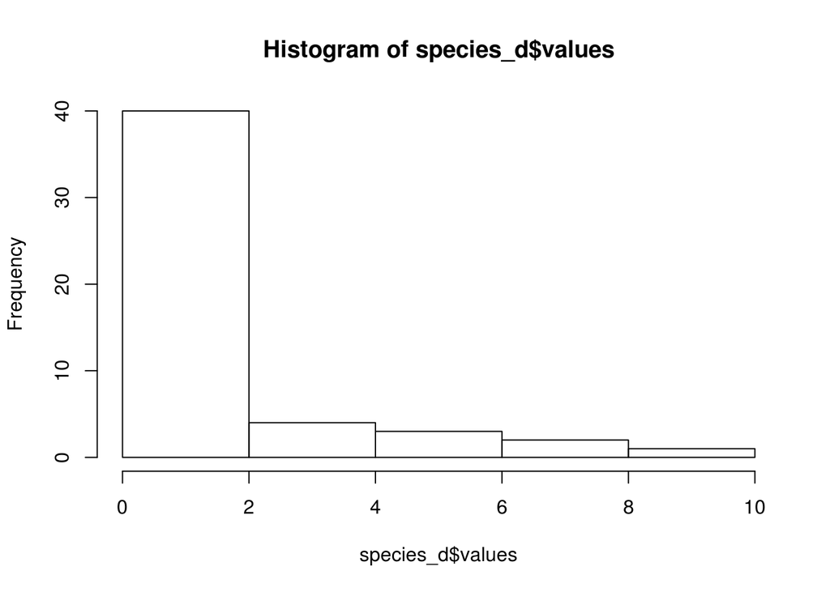

```r
# subset data
species_d <- subset(d, ind == 'Trichilia.pallida')

# visualize abundance data
hist(species_d$values)
```

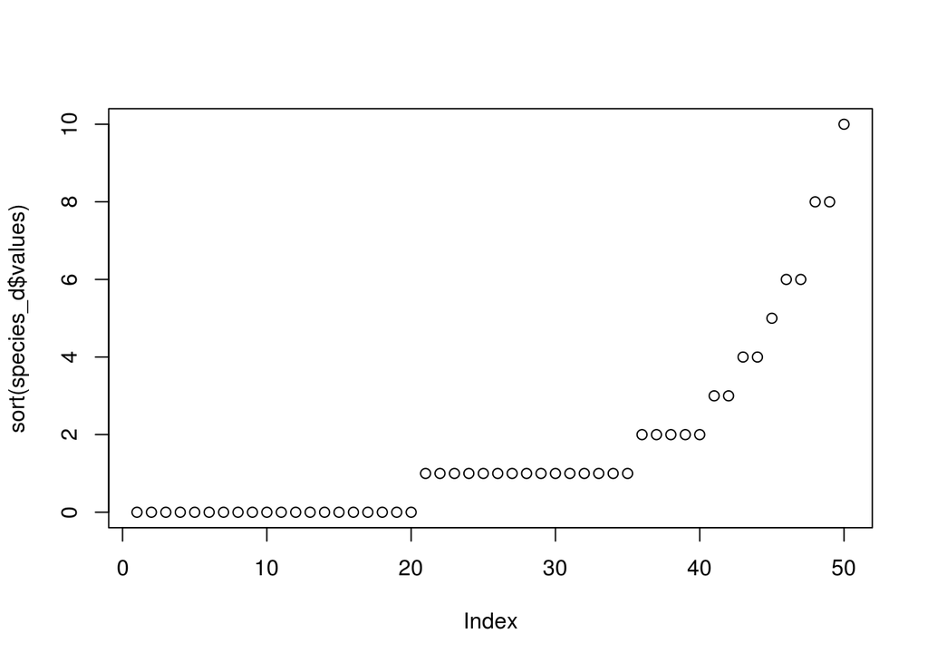

```r
plot(sort(species_d$values))
```

```r
# collect data for estimation
stan_d <- list(n = nrow(species_d), p = 1,
               X = matrix(1, nrow = nrow(species_d)),
               y = species_d$values)
out <- stan('poisson_glm.stan', data = stan_d)
```

Assessing convergence:

```r
out
```

```
## Inference for Stan model: poisson_glm.
## 4 chains, each with iter=2000; warmup=1000; thin=1;
## post-warmup draws per chain=1000, total post-warmup draws=4000.
##
##           mean se_mean   sd   2.5%    25%    50%    75%  97.5% n_eff Rhat
## beta[1]   0.49    0.00 0.11   0.26   0.42   0.49   0.56   0.70  1135 1.00
## lp__    -41.94    0.02 0.74 -44.02 -42.07 -41.65 -41.49 -41.45  1640 1.01
##
## Samples were drawn using NUTS(diag_e) at Sun Nov 22 19:44:02 2015.
## For each parameter, n_eff is a crude measure of effective sample size,
## and Rhat is the potential scale reduction factor on split chains (at
## convergence, Rhat=1).
```

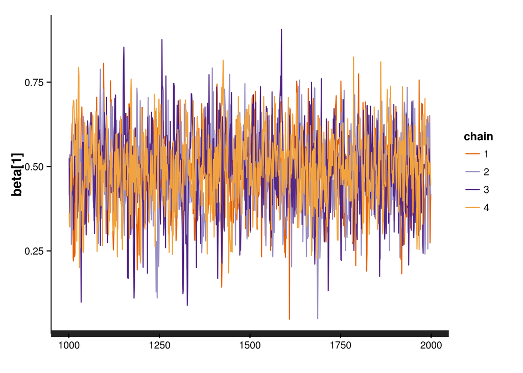

```r
traceplot(out)
```

```
## Showing 80% intervals
```

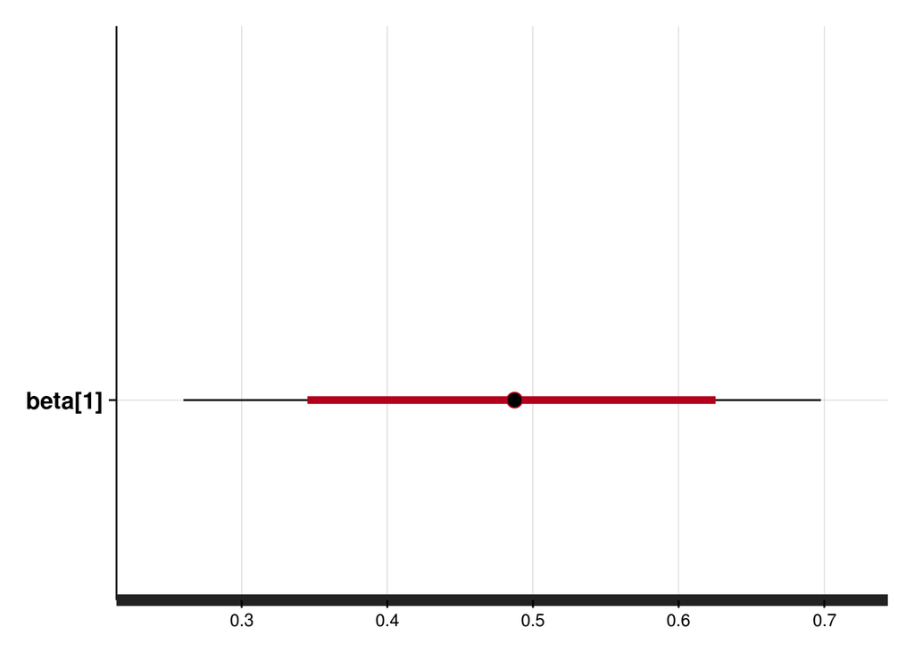

```r
plot(out)
```

Using a posterior predictive check for the variance of $y$:

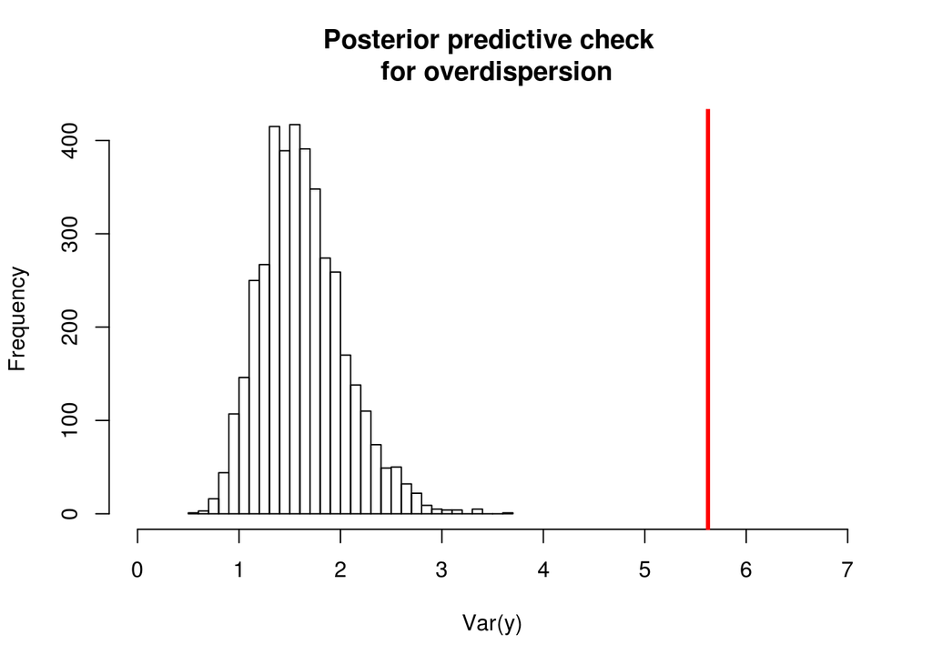

```r
post <- extract(out)

# simulate new observations and store variances
y_new <- array(dim=c(n_iter, n))
var_new <- rep(NA, n_iter)
for (i in 1:n_iter){
  y_new[i, ] <- rpois(n, exp(post$beta[i, 1]))
  var_new[i] <- var(y_new[i, ])
}

# compare distribution of simulated values to the empirical values
hist(var_new, breaks=40, xlab='Var(y)', xlim=c(0, 7),
     main='Posterior predictive check \n for overdispersion')
abline(v = var(stan_d$y), col=2, lwd=3)
```

As we can see, the observed variance is more than twice the expected variance under a Poisson model.

### Lognormal overdispersion

We will expand our model so that we can include some overdispersion. First, we will allow for additional plot-level variance by adding a term to our linear predictor:

$y \sim Poisson(\lambda)$

$log(\lambda) = X \beta + \epsilon$

$\epsilon \sim Normal(0, \sigma)$

$\sigma \sim halfCauchy(0, 2)$

Here, each observation $y_i$ has an associated parameter $\epsilon_i$ that has a normal prior, with a variance hyperparameter that determines how much extra-Poisson variance we have. If there is no overdispersion, then the posterior probability mass for $\sigma$ should be near zero. Our Stan model `poisson_od.stan` might be:

[output not shown]

Our data haven’t changed, but we do need to specify the path to this updated model:

```r
od_out <- stan('poisson_od.stan', data = stan_d)
```

```r
print(od_out, pars=c('sigma', 'beta', 'lp__'))
```

```
## Inference for Stan model: poisson_od.
## 4 chains, each with iter=2000; warmup=1000; thin=1;
## post-warmup draws per chain=1000, total post-warmup draws=4000.
##
##           mean se_mean   sd   2.5%    25%    50%    75%  97.5% n_eff Rhat
## sigma     1.20    0.01 0.23   0.80   1.04   1.19   1.34   1.73   726    1
## beta[1]  -0.15    0.01 0.26  -0.70  -0.33  -0.14   0.02   0.32   695    1
## lp__    -29.62    0.29 7.34 -44.96 -34.36 -29.30 -24.49 -15.91   630    1
##
## Samples were drawn using NUTS(diag_e) at Sun Nov 22 19:44:32 2015.
## For each parameter, n_eff is a crude measure of effective sample size,
## and Rhat is the potential scale reduction factor on split chains (at
## convergence, Rhat=1).
```

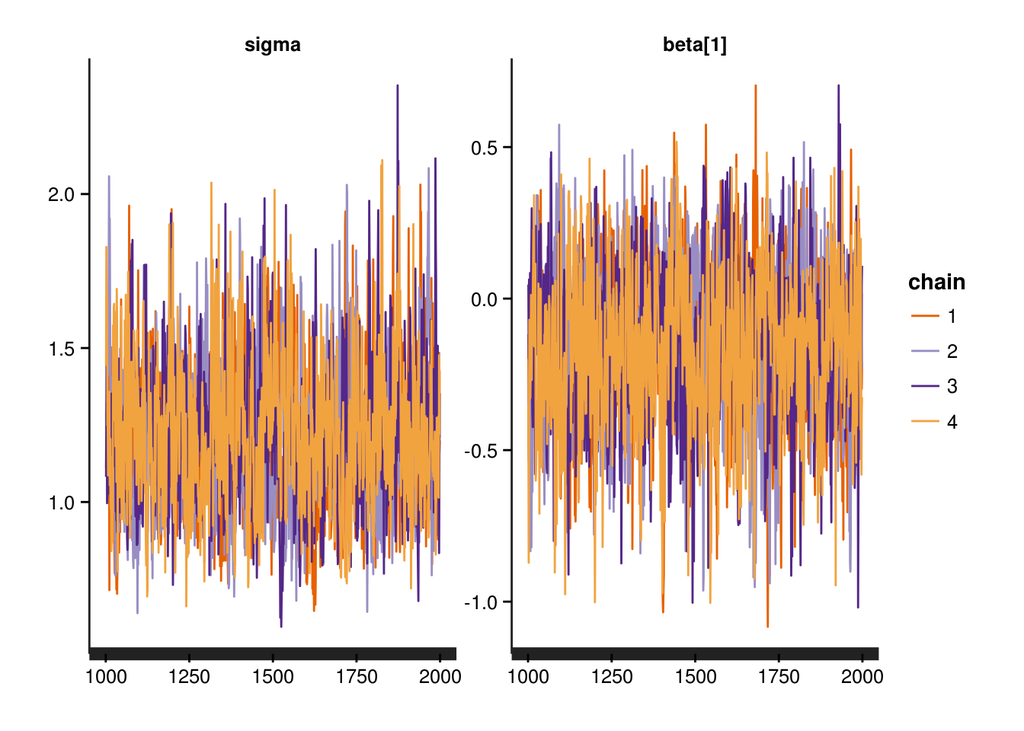

```r
traceplot(od_out, pars=c('sigma', 'beta'))
```

Using an updated posterior predictive check for the variance of $y$:

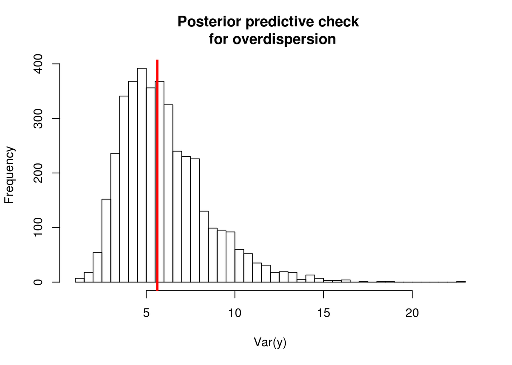

```r
post <- extract(od_out)

# simulate new observations and store variances
y_new <- array(dim=c(n_iter, n))
var_new <- rep(NA, n_iter)
for (i in 1:n_iter){
  y_new[i, ] <- rpois(n, exp(post$beta[i, 1] + post$epsilon[i, ]))
  var_new[i] <- var(y_new[i, ])
}

# compare distribution of simulated values to the empirical values
hist(var_new, breaks=40, xlab='Var(y)',
     main='Posterior predictive check \n for overdispersion')
abline(v = var(stan_d$y), col=2, lwd=3)
```

That looks much better. The variance that we get from our replicated simulations is entirely consistent with the variance that we actually observed.

### Poisson-gamma overdispersion and the negative binomial

The negative binomial distribution can be thought of as a Poisson distribution with a gamma prior on $\lambda$.

$y \sim Poisson(\lambda)$

$\lambda \sim Gamma(\alpha, \beta)$

To give a sense of what this looks like, here are some gamma distributions with varying parameters:

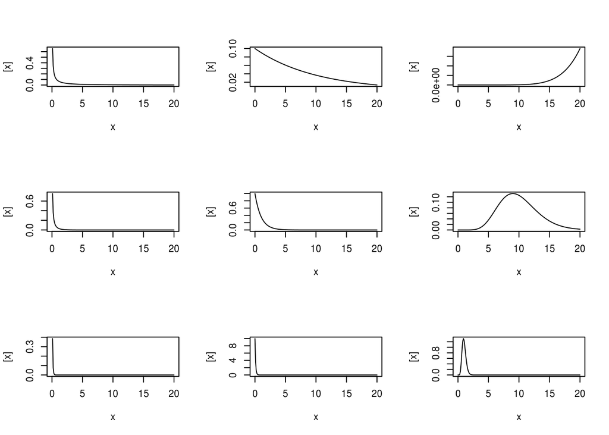

```r
alpha <- c(.1, 1, 10)
beta <- c(.1, 1, 10)
g <- expand.grid(alpha = alpha, beta = beta)
x <- seq(0, 20, .1)
par(mfrow=c(3, 3))
for (i in 1:9){
  plot(x, dgamma(x, g$alpha[i], g$beta[i]), type='l',
       ylab='[x]')
}
```

We could implement this directly in Stan, but it would be easier to use the built-in and optimized negative binomial distribution function, which is parameterized in terms of its mean $\mu$ and precision $\phi$:

$y \sim NegBinom(\mu, \phi)$

$log(\mu) = X \beta$

```
data {
  int n; // sample size
  int p; // number of coefficients
  matrix[n, p] X;
  int y[n];
}

parameters {
  vector[p] beta;
  real<lower=0> phi;
}

model {
  beta ~ normal(0, 3);
  phi ~ cauchy(0, 5);
  y ~ neg_binomial_2_log(X * beta, phi);
}
```

With this `nb_glm.stan` file in hand, we can fit the model as before:

```r
nb_out <- stan('nb_glm.stan', data = stan_d)
```

```r
nb_out
```

```
## Inference for Stan model: nb_glm.
## 4 chains, each with iter=2000; warmup=1000; thin=1;
## post-warmup draws per chain=1000, total post-warmup draws=4000.
##
##           mean se_mean   sd   2.5%    25%    50%    75%  97.5% n_eff Rhat
## beta[1]   0.50    0.00 0.20   0.12   0.37   0.50   0.62   0.89  1944 1.01
## phi       0.84    0.01 0.32   0.41   0.62   0.78   0.98   1.63  1795 1.00
## lp__    -20.79    0.04 1.02 -23.55 -21.18 -20.48 -20.07 -19.80   748 1.01
##
## Samples were drawn using NUTS(diag_e) at Sun Nov 22 19:45:02 2015.
## For each parameter, n_eff is a crude measure of effective sample size,
## and Rhat is the potential scale reduction factor on split chains (at
## convergence, Rhat=1).
```

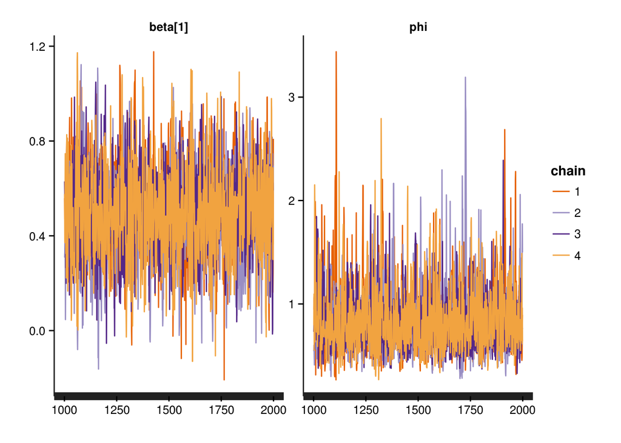

```r
traceplot(nb_out)
```

Conducting our posterior predictive check:

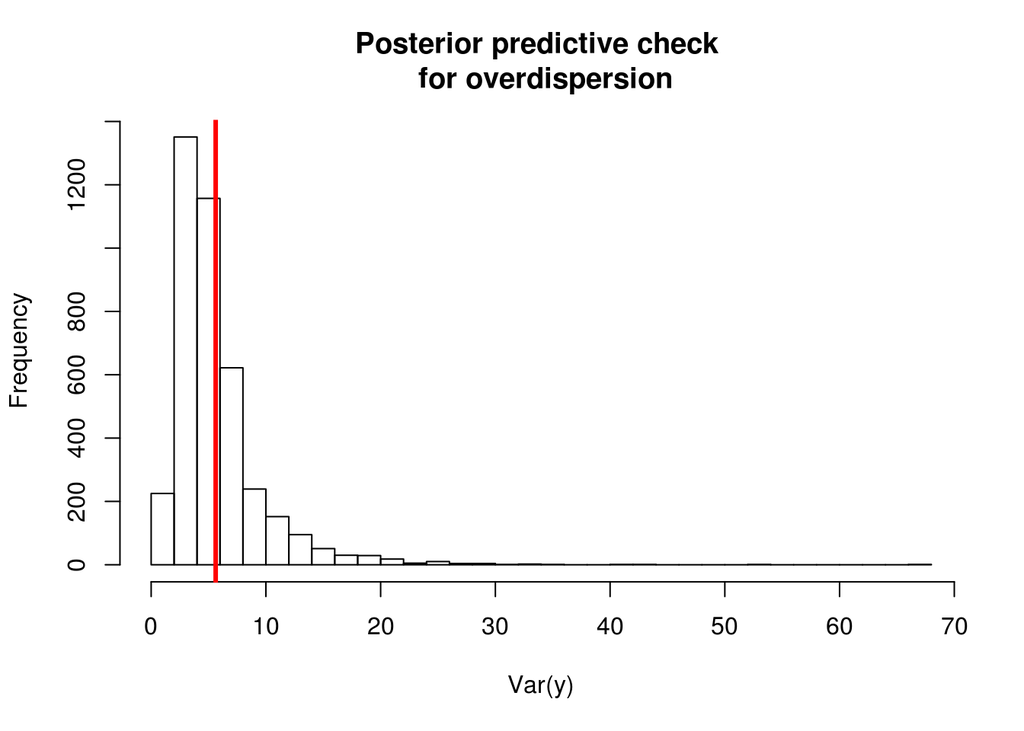

```r
post <- extract(nb_out)

# simulate new observations and store variances
y_new <- array(dim=c(n_iter, n))
var_new <- rep(NA, n_iter)
for (i in 1:n_iter){
  y_new[i, ] <- rnbinom(n, mu = exp(post$beta[i, 1]), size = post$phi[i])
  var_new[i] <- var(y_new[i, ])
}

# compare distribution of simulated values to the empirical values
par(mfrow=c(1, 1))
hist(var_new, breaks=40, xlab='Var(y)',
     main='Posterior predictive check \n for overdispersion')
abline(v = var(stan_d$y), col=2, lwd=3)
```

Again, the variance in the replicated datasets that are simulated from the posterior predictive distribution is now consistent with the variance in the observed data.